# Sustained improved survival of patients with metastatic melanoma after the introduction of anti-PD-1-based therapies

¶ Prognostic predictive model figures and tables ¶

Aimilia Schina

First created on May 2022. Updated on 29 December 2023

```r
# Clear R-workspace
rm(list=ls(all=TRUE))

## Close all graphic devices
graphics.off()
#####################
### Load packages ###
#####################
library(pacman)

pacman::p_load(extrafont,DT, dplyr,data.table, tibble,reshape2, ggplot2,hrbrthemes,ggpubr, RColorBrewer,readxl,survival,gtsummary,ggrepel,forcats,mosaic,stringr,plyr,rcompanion,rlang,tidytidbits, purrr, forestmodel,rms,riskRegression,magrittr,tidymodels,base.rms,dynpred,ezfun,formula.tools,GGally,dcurves,patchwork, survminer,str2str,VIM,mice,flextable,officer, prodlim)

extrafont::loadfonts(device="win")
windowsFonts(sans="Palatino Linotype")
loadfonts(device="win")
loadfonts(device="postscript")
```

```r
###########################
### Main analysis paths ###
###########################

scriptsPath <- paste0("scripts/")
scriptsFunctionsPath <- paste0(scriptsPath,"functions/")
projectDataPath <- paste0("data/")
projectOutDataPath <- paste0("output/data_files/")
figuresPath <- paste0("output/figures/")
tablesPath <- paste0("output/tables/")
modelsPath <- paste0("output/models/")
sessionInfoPath <- paste0("session_info/")


##################################
### LOAD SOURCE FUNCTIONS FILE ###
##################################
source(paste0(scriptsFunctionsPath,"generic_helper_functions.R"))
source(paste0(scriptsFunctionsPath,"performance_measures_Cox_functions.R"))
source(paste0(scriptsFunctionsPath,"visualization_functions.R"))
source(paste0(scriptsFunctionsPath,"stdca.R"))
source(paste0(scriptsFunctionsPath,"customtab.R"))

#####################
### File suffixes ###
#####################
Rdata.suffix <- ".RData"
```

# 1 Data

## 1.1 Loading patient data

Original dataframe is reduced to include only patients diagnosed in 2016 and 2018.

```r
# Loading data
dataDF <- loadRData(paste0(projectOutDataPath,"realMel.DF.allCont",Rdata.suffix))
dataDF.fix <-dataDF
colnames(dataDF.fix) <- str_replace_all(str_replace_all(colnames(dataDF.fix)," ","_"),"-","_")

dataDF.f <- dataDF.fix %>% dplyr::select(-eligible) %>% dplyr::filter(Year_of_diagnosis %in% c(2016,2018)) %>% droplevels()
levels(dataDF.f$Gender) <- c("Male","Female")
```

## 1.2 Preprocessing

We remove treatments of no interest.

```r
treats=c("Anti-PD-1","Anti-PD-1 plus Anti-CTLA-4","BRAFi", "No treatment")


colnames(dataDF.f)[11] <- "LDH"
colnames(dataDF.f)[18] <- "LDH_level"
dataDF.f <- dataDF.f %>% relocate(LDH, .after = LDH_level) %>% droplevels()
dataDF.f <- dataDF.f %>% dplyr::filter(First_line_treatments %in% treats) %>% droplevels()
```

We will use the multiply imputed data (1000 imputations) (pooled in the sense that they are complete) for initial descriptive statistics, model diagnostics, interactions etc.

Then we will use the imputed bootstrapped data for predicting survival times.

Age and LDH will be kept as continuous variables, and explore possible transformations suitable.

Data include patients that received:

- no treatment
- anti-PD-1
- anti-PD-1 plus anti-CTLA-4
- BRAF inhibitors

```r
data.all <- dataDF.f
```

## 1.3 Features

```r
## Define which columns include survival data
OS_time <- c("Months_to_death_or_last_seen")
OS_status <- c("Dead_or_alive")
# PFS_time <- c("PFS FU MONTHS")
# PFS_status <- c("PROGRESSED")
## DEFINE IF YOU ARE DOING OS OR PFS
surv_time <-OS_time
surv_status <-OS_status
surv_time_label <- "OS"
# Set prediction horizons
myHorizons = c(6,12,24,36,48)
```

Combine brain metastases with disease stage to one covariate.

```r
data.all$Stage_Brain_mets <- paste(data.all$Disease_stage,"_",data.all$Brain_metastases) %>% str_remove_all(" ")
# Create combined variable for Brain mets and disease stage (strata also for treatment)

data.all$Stage_Brain_mets <- ifelse(data.all$Stage_Brain_mets=="M1c/M1d_yes",
                                                                              "M1c/M1d with BM",
                                             ifelse(data.all$Stage_Brain_mets=="M1c/M1d_no",
                                                    "M1c/M1d no BM",
                                                    ifelse(data.all$Stage_Brain_mets=="III/M1a/M1b_no",
                                                           "III/M1a/M1b",data.all$Stage_Brain_mets)))
data.all$Stage_Brain_mets <- factor(data.all$Stage_Brain_mets,
                                             levels=c("M1c/M1d with BM","M1c/M1d no BM","III/M1a/M1b"))

data.all$STAGE <- as.factor(data.all$STAGE)
```

```r
# # Brain mets full
# featuresIn.cn <-c("Gender","Age_at_1st_Treatment","BRAF status",
#               "Stage_Brain_mets","LDH_level","Performance status","Steroids","Comorbidities","Autoimmunity","Other malignancies","First_line_treatments")
# featuresIn.cn <- str_replace_all(str_replace_all(featuresIn.cn," ","_"),"-","_")
# featuresInLabels.cn <- c("Gender","Age","BRAF status",
#               "Disease stage and Brain metastases","LDH level","Performance status","Steroids","Comorbidities","Autoimmunity","Other malignancies","First line Treatment")
#
# numeric_feats<- c("Age_at_1st_Treatment","LDH_level")
# categ_feats <- setdiff(featuresIn.cn,numeric_feats)
```

## 1.4 Final data

```r
# Fix original data column to not have issue when extracting knots
colnames(data.all)[5]<- "Age_first_Treatment"
```

```r
table(data.all$First_line_treatments)
```

```
##
##               No treatment                  Anti-PD-1
##                        102                        306
## Anti-PD-1 plus Anti-CTLA-4                      BRAFi
##                         90                        116
```

```r
dim(data.all)
```

```
## [1] 614  19
```

```r
table(data.all$Dead_or_alive)
```

```
##
##   0   1
## 182 432
```

```r
# 432/614 * 100
```

# 2 Load results of internal validation and calibration

Internal validation

```r
## Treatment strata, REDUCED
resCox_MI_boot.strata.nointer_RED <-loadRData(paste0(modelsPath,"resCox_MI_boot.strata.nointer" ,"_RED",Rdata.suffix))
resCox_MI_boot.strata.nointer.bw_RED<-loadRData(paste0(modelsPath,"resCox_MI_boot.strata.nointer.bw" ,"_RED",Rdata.suffix))
```

Internal calibration

```r
## Treatment strata, REDUCED
res.cal.strat.nointer_RED <- loadRData(paste0(modelsPath,"res.cal.strat.nointer","_RED" ,Rdata.suffix))
```

Final models for net benefit

```r
finalModel_noInter<- loadRData(paste0(modelsPath,"finalModel_noInter","_RED" ,Rdata.suffix))
```

# 3 Performance plots - MICE-compare internal

## 3.1 Treatment strata

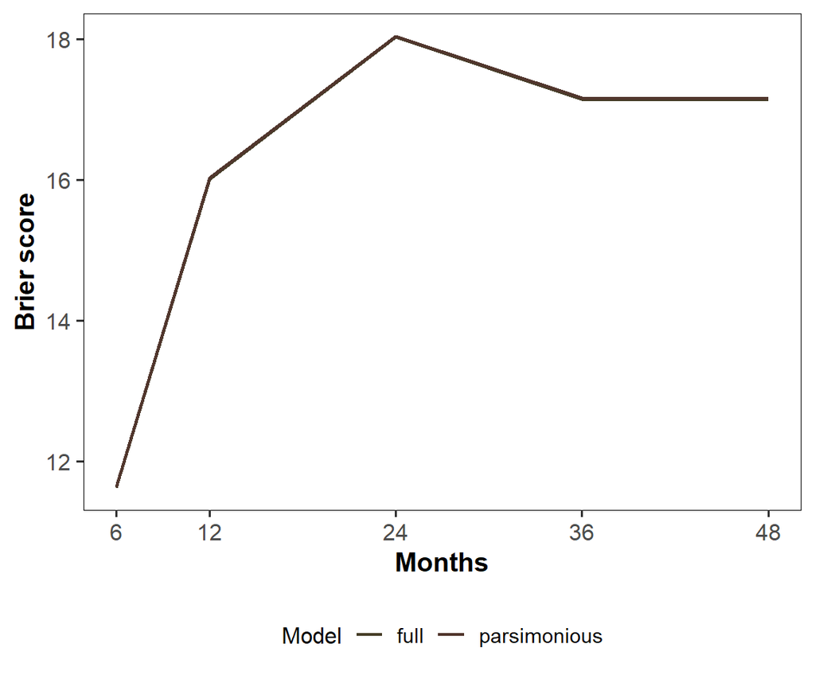

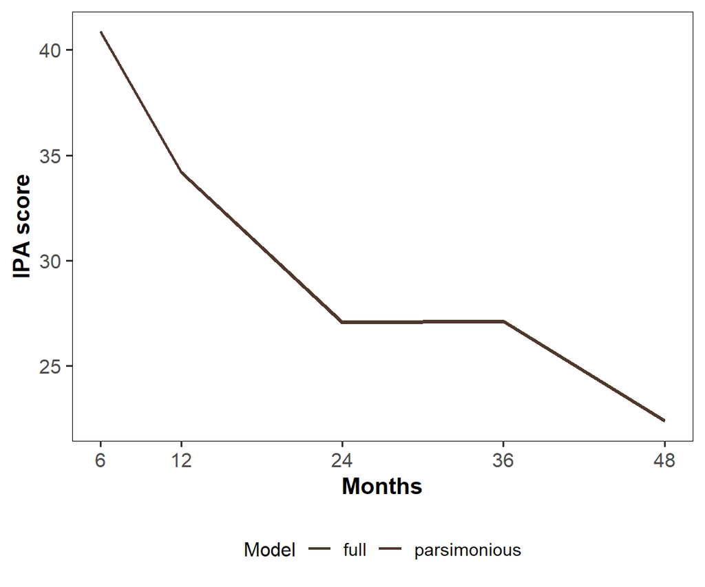

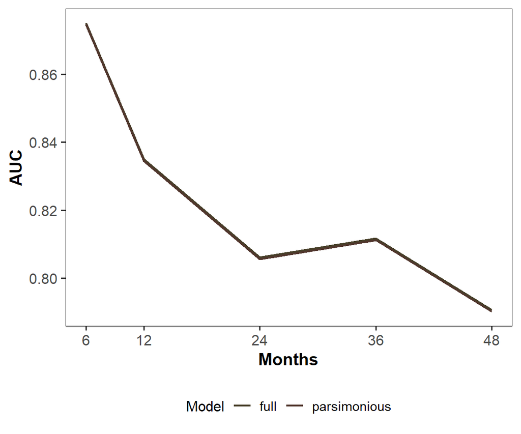

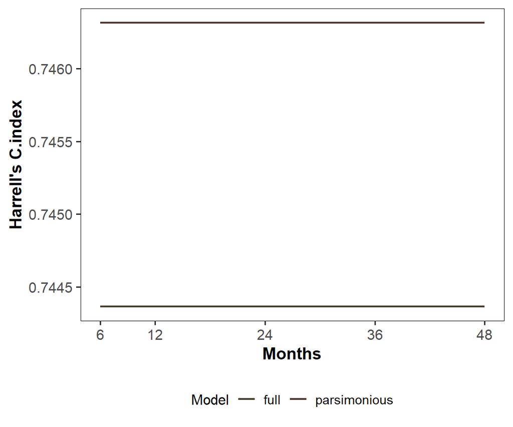

```r
resCox_treat_red <- c(list(full=resCox_MI_boot.strata.nointer_RED$mice),
                          list(parsimonious=resCox_MI_boot.strata.nointer.bw_RED$mice.bw))



bootMI.scores_treat_red<-sapply(1:length(resCox_treat_red), function(x) postProcessing_scores(resCox_treat_red[[x]],modelName=names(resCox_treat_red)[x]), simplify=FALSE)

bootMI.scores.merged_treat_red <- ldply(bootMI.scores_treat_red)

plotMeasures_byTimeBoot(bootMI.scores.merged_treat_red, horizons=myHorizons,metric="brier",timesLabel="Months",palleteName="neutral",filterModels=NULL,scale=FALSE)

plotMeasures_byTimeBoot(bootMI.scores.merged_treat_red, horizons=myHorizons,metric="ipa",timesLabel="Months",palleteName="neutral",filterModels=NULL,scale=FALSE)

plotMeasures_byTimeBoot(bootMI.scores.merged_treat_red, horizons=myHorizons,metric="auc",timesLabel="Months",palleteName="neutral",filterModels=NULL,scale=FALSE)

plotMeasures_byTimeBoot(bootMI.scores.merged_treat_red, horizons=myHorizons,metric="c",timesLabel="Months",palleteName="neutral",filterModels=NULL,scale=FALSE)
```

# 4 Performance plots-mice: final selection

## 4.1 Treatment strata: full , no interactions

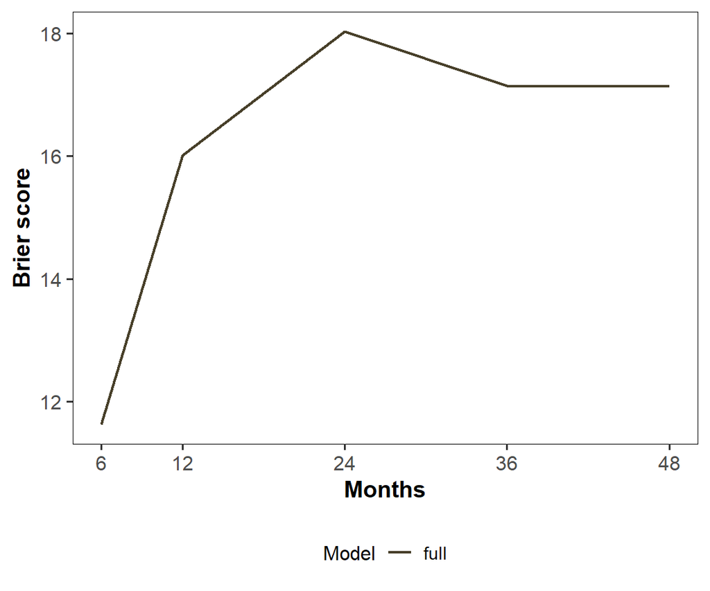

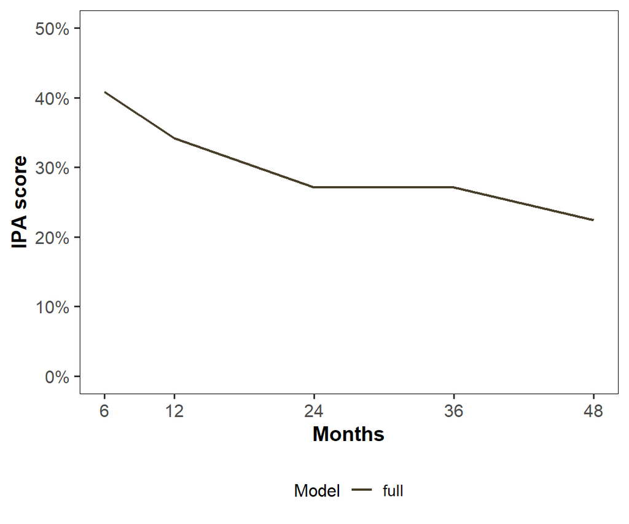

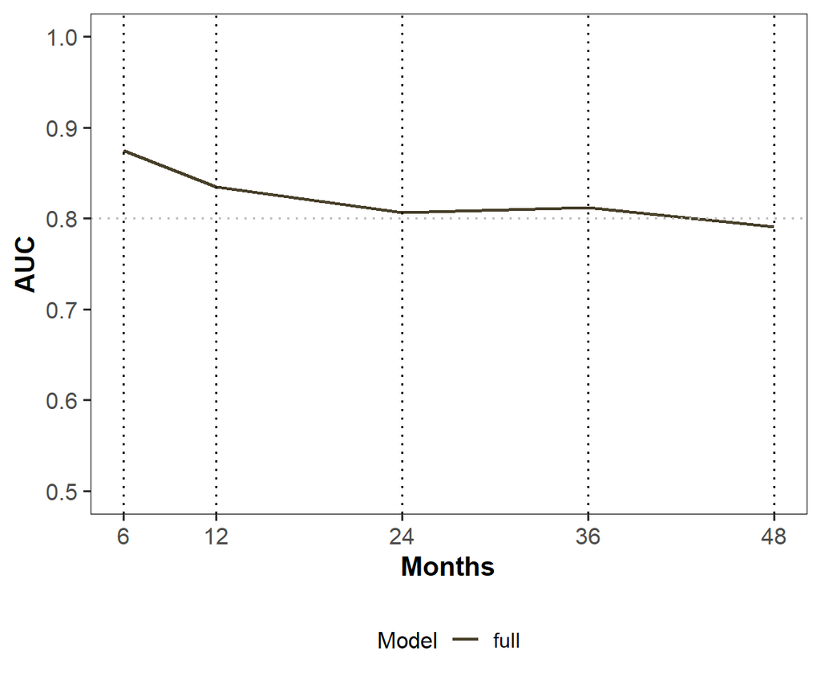

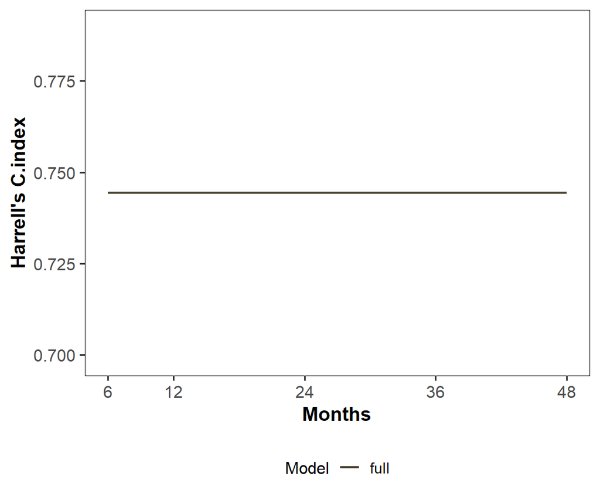

```r
resCox_treat_red <- c(list(full=resCox_MI_boot.strata.nointer_RED$mice))


bootMI.scores<-sapply(1:length(resCox_treat_red), function(x) postProcessing_scores(resCox_treat_red[[x]],modelName=names(resCox_treat_red)[x]), simplify=FALSE)

bootMI.scores.merged <- ldply(bootMI.scores)



plotMeasures_byTimeBoot(bootMI.scores.merged, horizons=myHorizons,metric="brier",timesLabel="Months",palleteName="neutral",filterModels=NULL,scale=FALSE)

plotMeasures_byTimeBoot(bootMI.scores.merged, horizons=myHorizons,metric="ipa",timesLabel="Months",palleteName="neutral",filterModels=NULL,scale=TRUE)

plotMeasures_byTimeBoot(bootMI.scores.merged, horizons=myHorizons,metric="auc",timesLabel="Months",palleteName="neutral",filterModels=NULL,scale=TRUE,vlines = c(6,12,24,36, 48))

plotMeasures_byTimeBoot(bootMI.scores.merged, horizons=myHorizons,metric="c",timesLabel="Months",palleteName="neutral",filterModels=NULL,scale=FALSE)
```

## 4.2 Treatment strata: BW, no interactions,

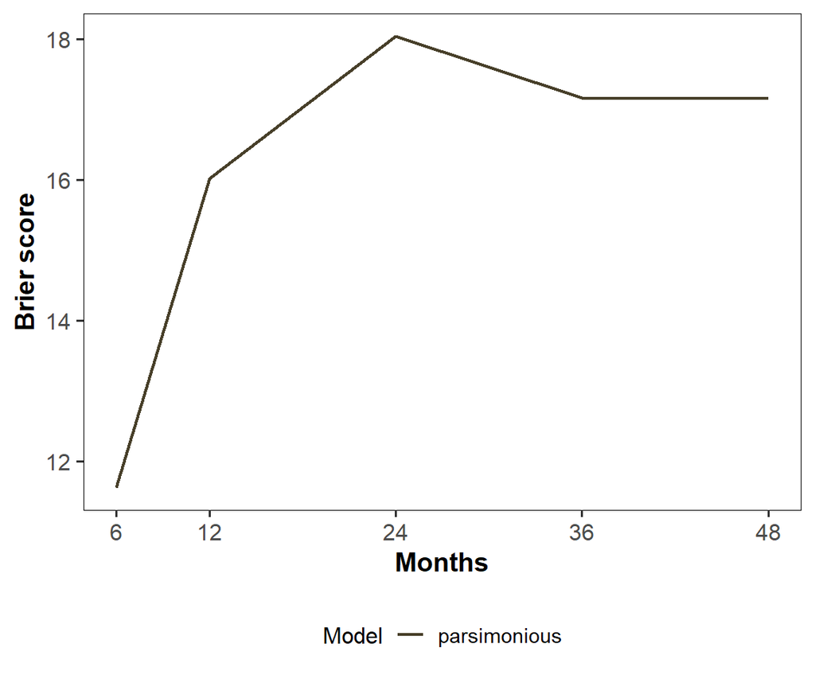

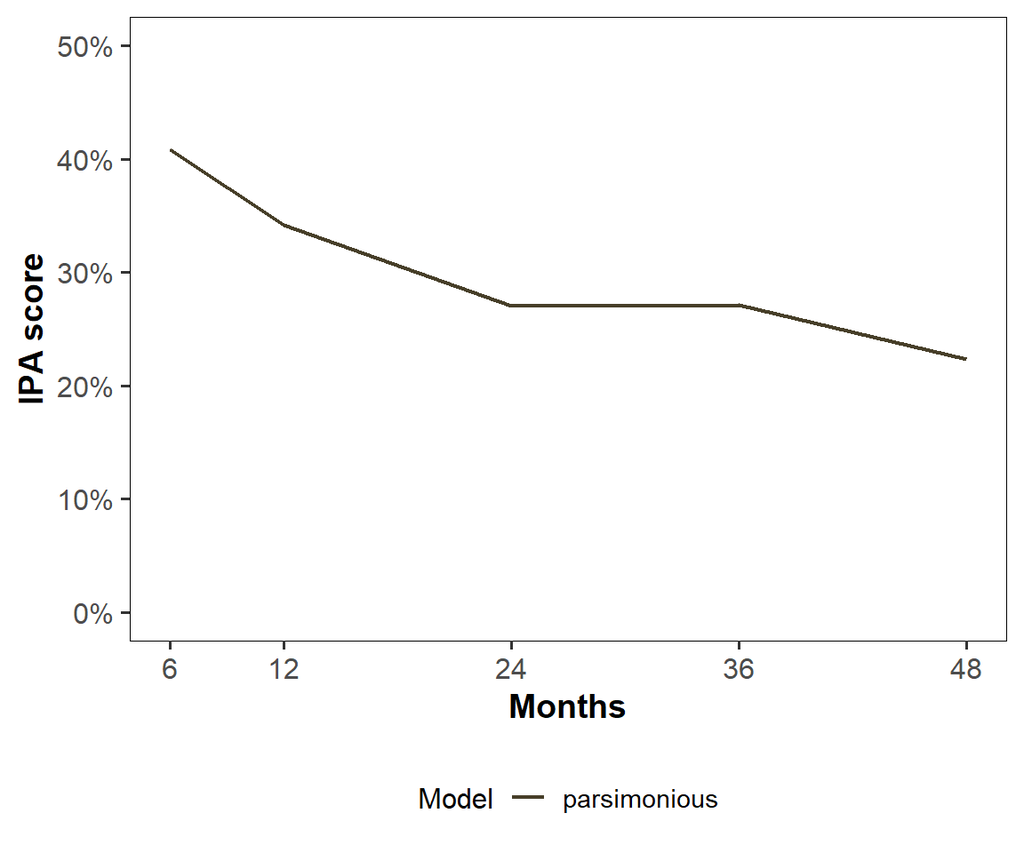

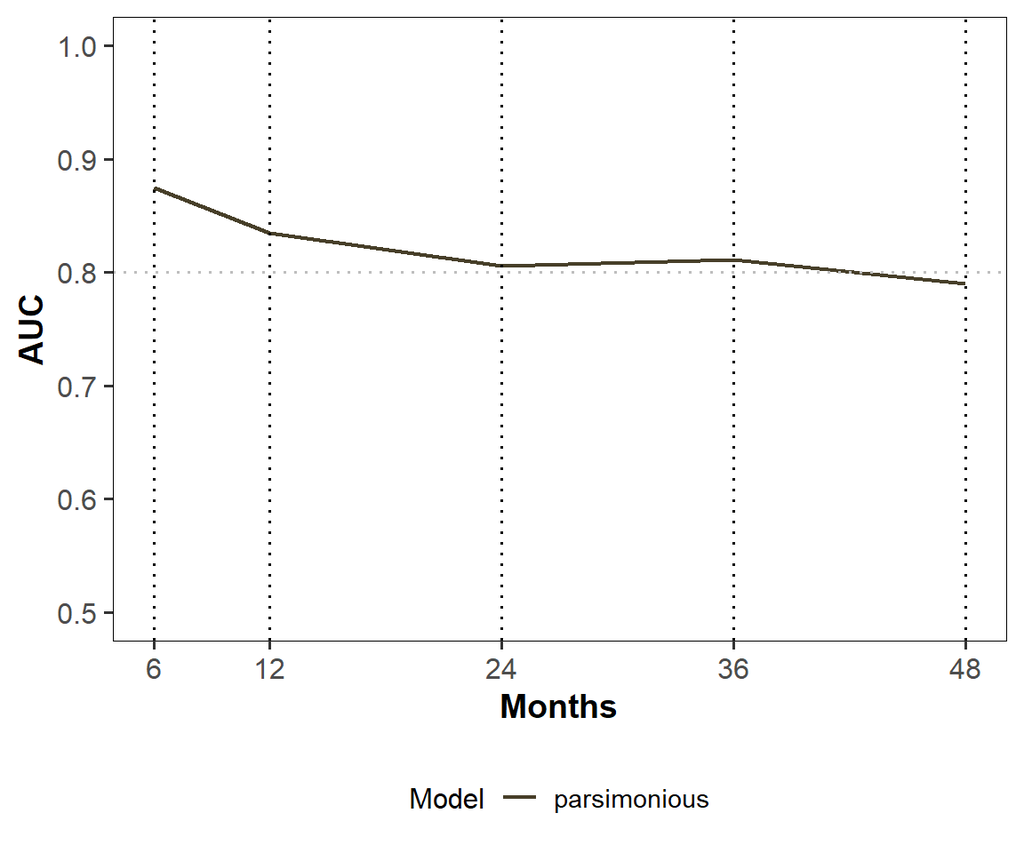

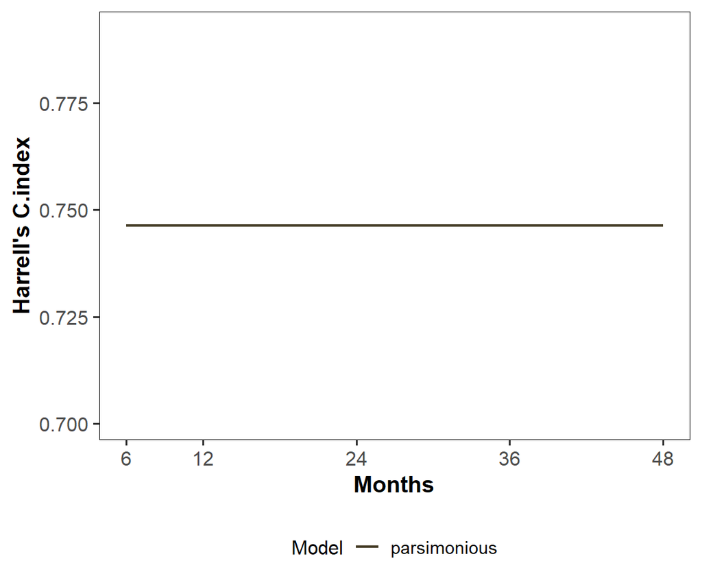

```r
resCox_treat_red.bw <- c(list(parsimonious=resCox_MI_boot.strata.nointer.bw_RED$mice))


bootMI.scores_treat_red.bw<-sapply(1:length(resCox_treat_red.bw), function(x) postProcessing_scores(resCox_treat_red.bw[[x]],modelName=names(resCox_treat_red.bw)[x]), simplify=FALSE)

bootMI.scores.merged_treat_red.bw <- ldply(bootMI.scores_treat_red.bw)

plotMeasures_byTimeBoot(bootMI.scores.merged_treat_red.bw, horizons=myHorizons,metric="brier",timesLabel="Months",palleteName="neutral",filterModels=NULL,scale=FALSE)

plotMeasures_byTimeBoot(bootMI.scores.merged_treat_red.bw, horizons=myHorizons,metric="ipa",timesLabel="Months",palleteName="neutral",filterModels=NULL,scale=TRUE)

plotMeasures_byTimeBoot(bootMI.scores.merged_treat_red.bw, horizons=myHorizons,metric="auc",timesLabel="Months",palleteName="neutral",filterModels=NULL,scale=TRUE,vlines = c(6,12,24,36, 48))

plotMeasures_byTimeBoot(bootMI.scores.merged_treat_red.bw, horizons=myHorizons,metric="c",timesLabel="Months",palleteName="neutral",filterModels=NULL,scale=FALSE)
```

# 5 Calibration plots final

## 5.1 Treatment strata, BW model

```r
cal.treat_strata.red.bw <-calibrationGGplot_TEST(calObj=res.cal.strat.nointer_RED$mice.bw$`48`$cal,optCorColor="Orange")
```

```
## [1] 0.7 0.7
```

```r
cal.treat_strata.red.bw
```

```
## [1] 0.7 0.7
```

```r
###############
# calibrationGGplot_TEST(calObj=res.cal.strat.nointer_RED$mice.bw$`48`$cal,optCorColor="Orange")
#
# calibrationGGplot_TEST(calObj=res.cal.strat.nointer_RED$mice$`48`$cal,optCorColor="Orange")

###############
cal.treat_strata.red.compl <-calibrationGGplot_TEST(calObj=res.cal.strat.nointer_RED$mice$`48`$cal,optCorColor="Orange")
```

```
## [1] 0.7 0.7
```

```r
cal.treat_strata.red.compl
```

```
## [1] 0.7 0.7
```

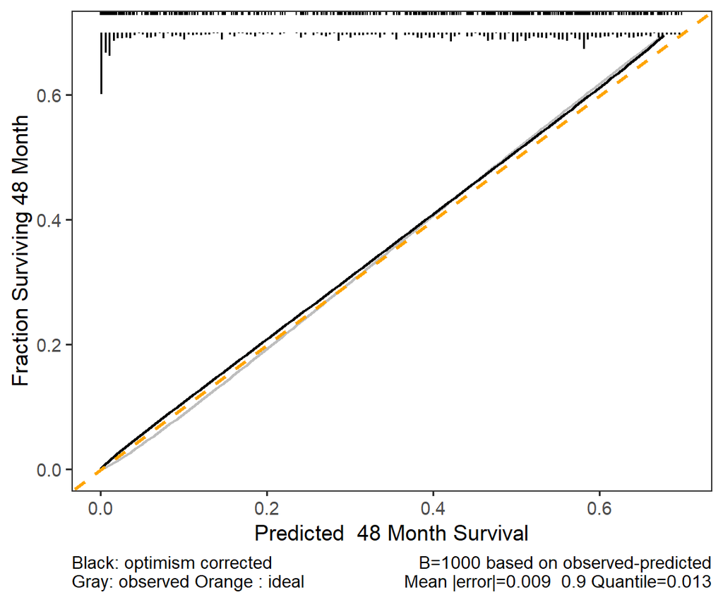

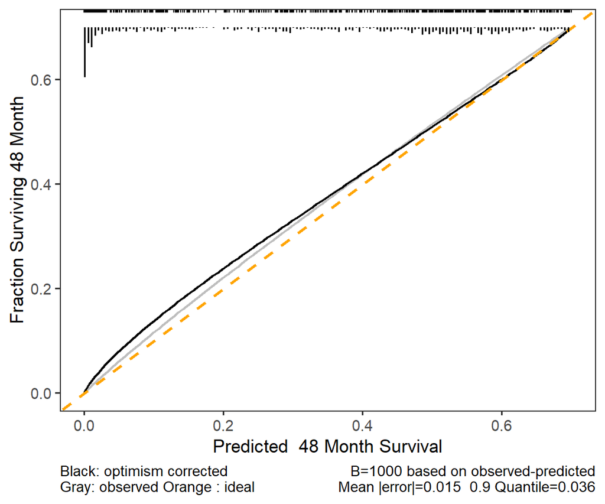

```r
cal.treat_strata.red.bw <-calibrationGGplot(calObj=res.cal.strat.nointer_RED$mice.bw$`48`$cal,optCorColor="Orange")
cal.treat_strata.red.bw

calibrationGGplot(calObj=res.cal.strat.nointer_RED$mice$`48`$cal,optCorColor="Orange")
```

# 6 Net benefit final

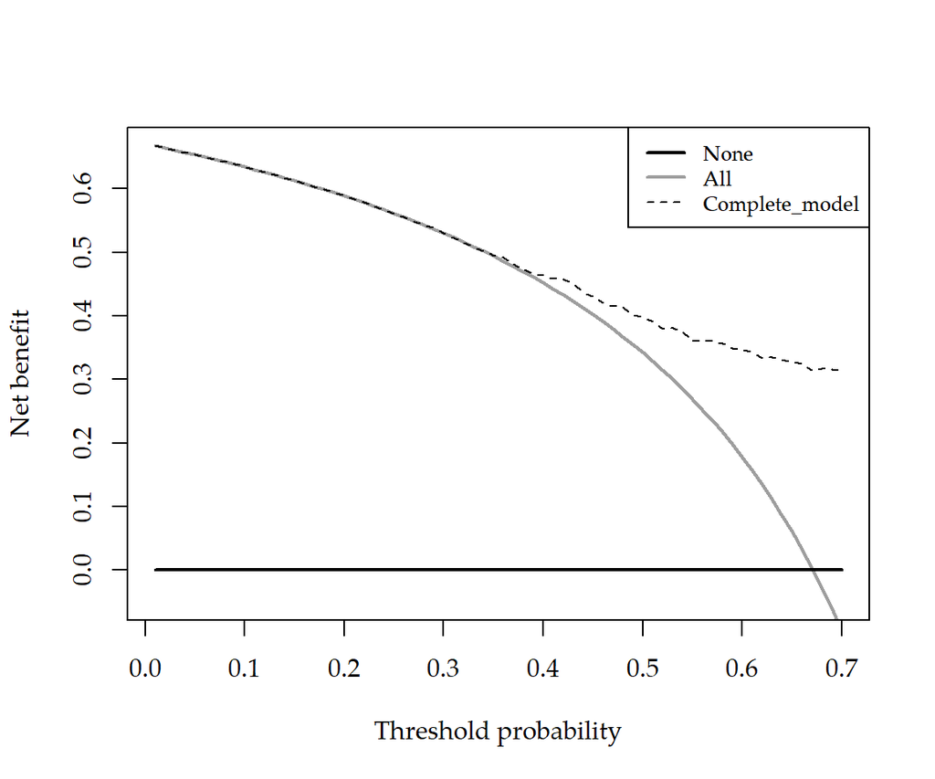

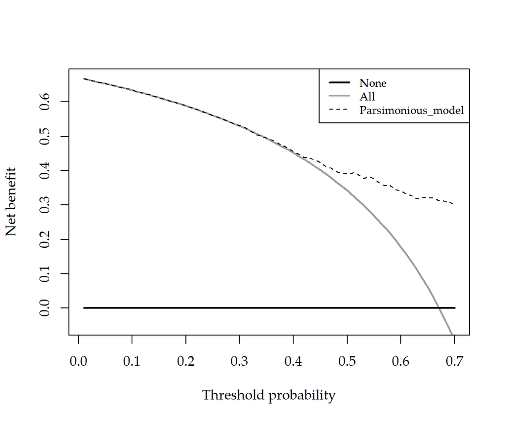

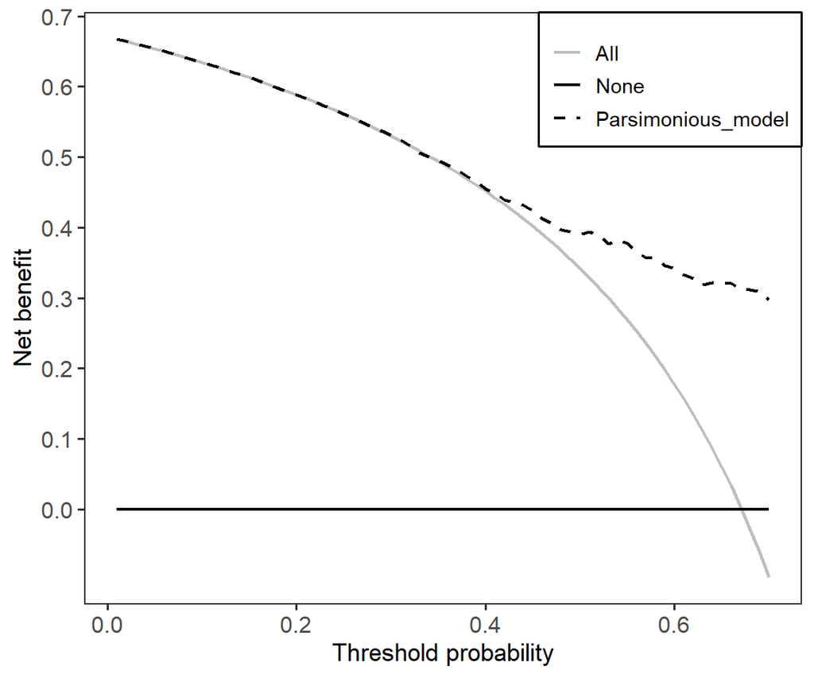

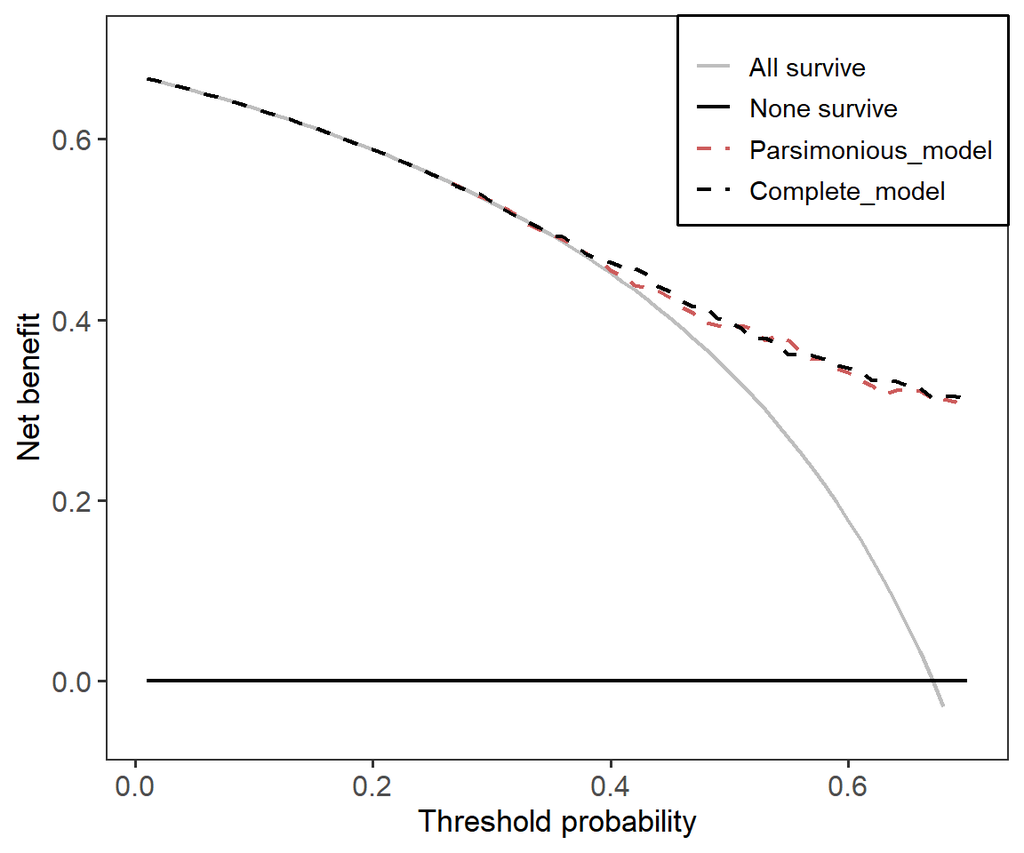

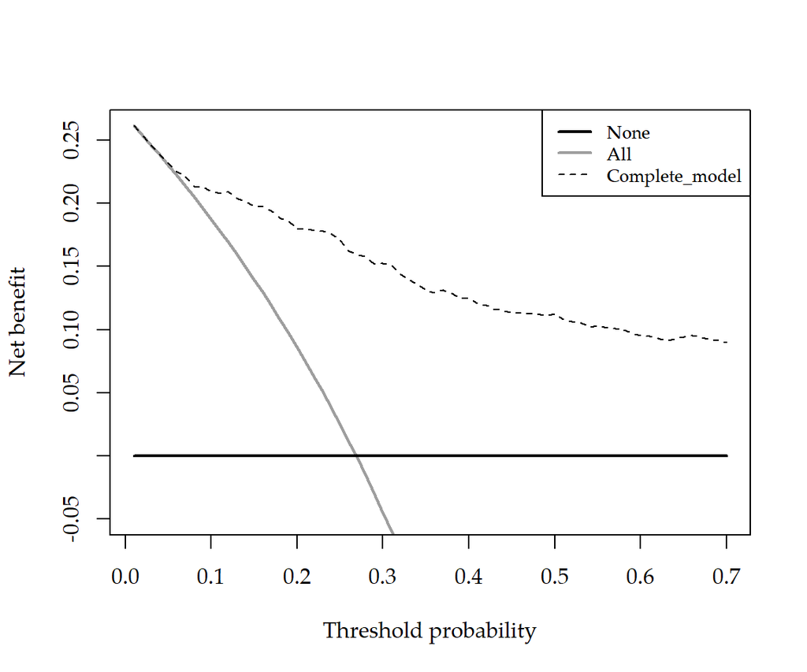

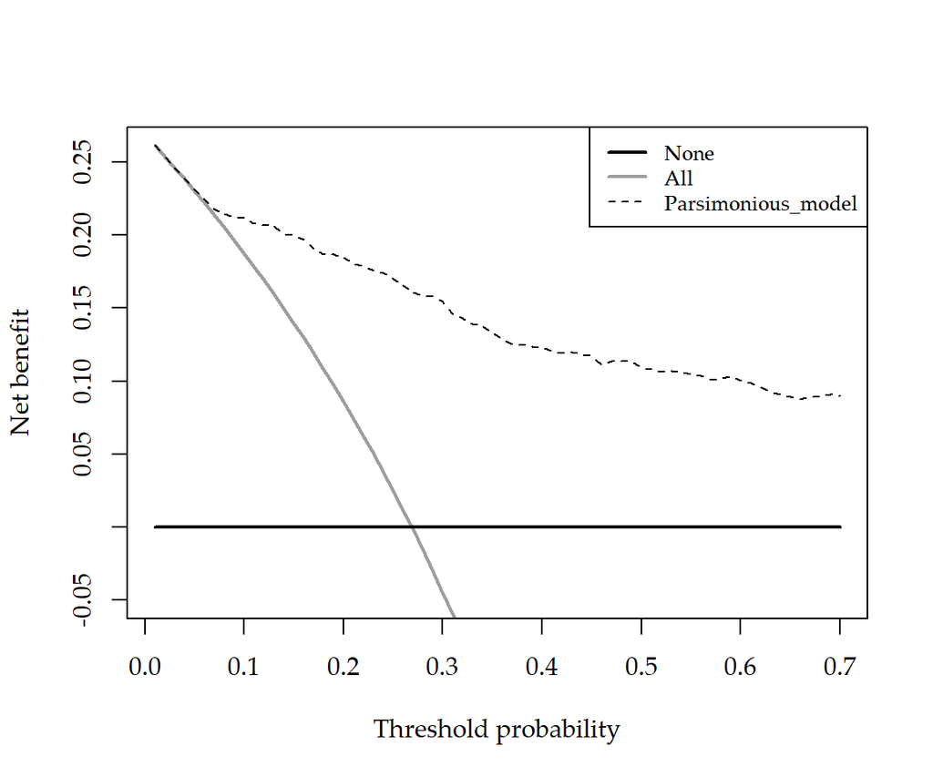

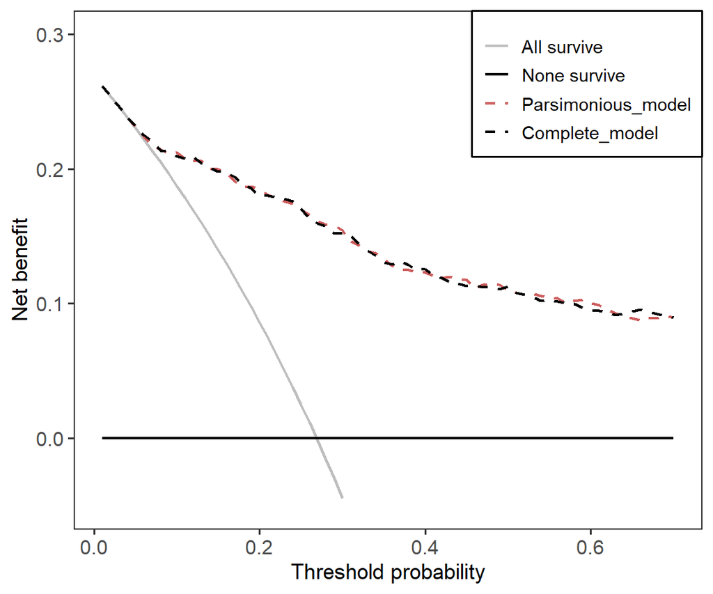

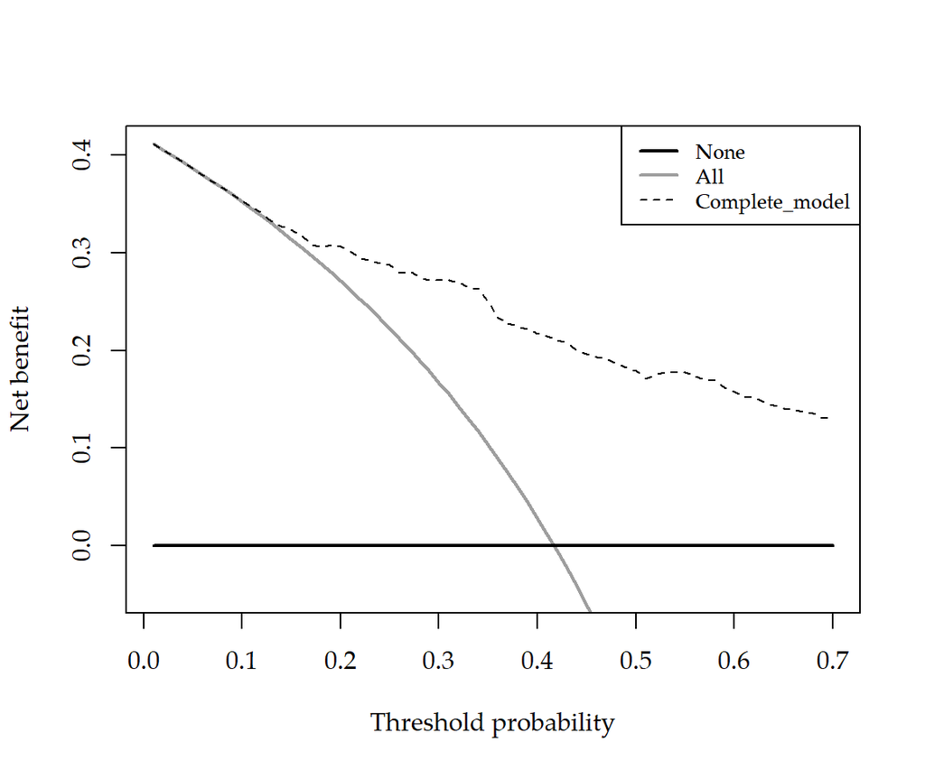

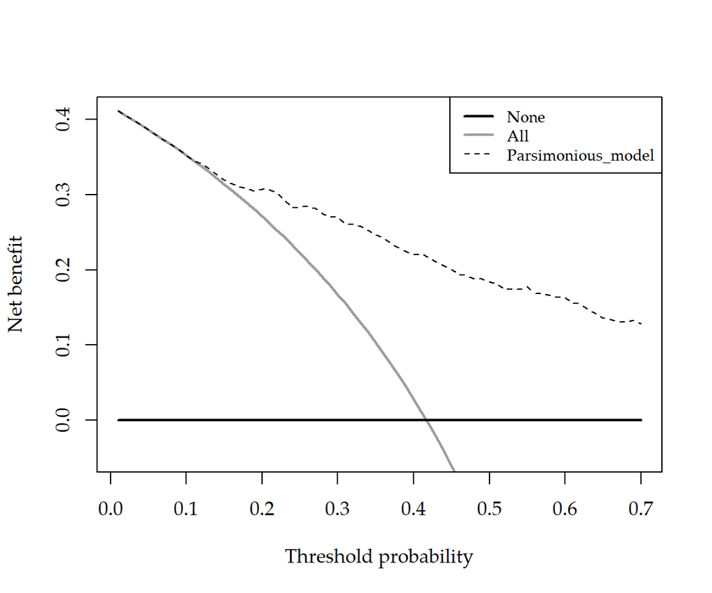

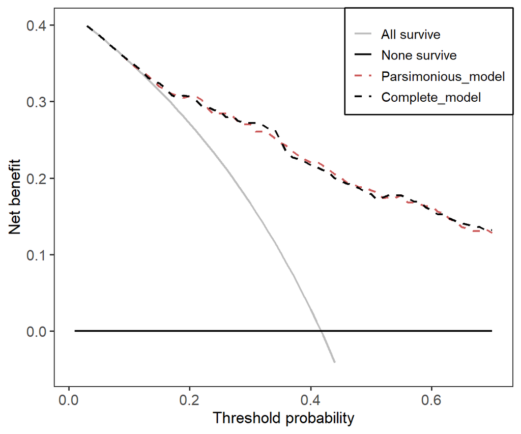

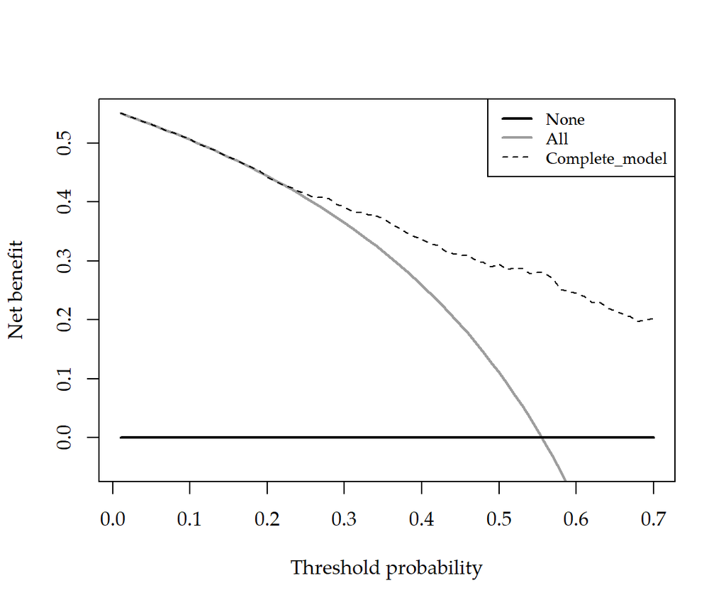

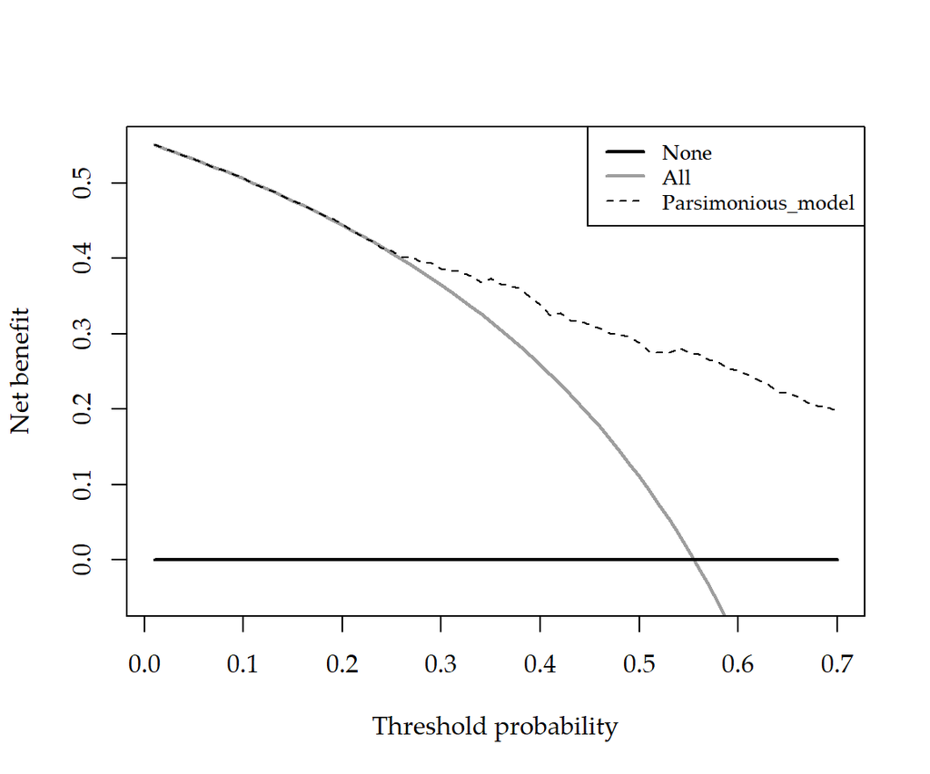

[4 more figures not shown]

```r
# No BW
netB.strata.nointer.nobw<- myDCA(data=finalModel_noInter$si_data, testdata=finalModel_noInter$si_data,
      fitObj=finalModel_noInter$nobw, time=surv_time, status=surv_status,
      manualCalc=F,
      timePoint=48,
      features=finalModel_noInter$feats_nobw.c,
      predName="Complete_model")

# With BW
netB.strata.nointer.bw<- myDCA(data=finalModel_noInter$si_data, testdata=finalModel_noInter$si_data,
      fitObj=finalModel_noInter$bw, time=surv_time, status=surv_status,
      manualCalc=F,
      timePoint=48,
      features=finalModel_noInter$feats_bw.c,
      predName="Parsimonious_model")

netB.bw.plot<-myDCAggPlot(stdcaObj=netB.strata.nointer.bw,predictors="Parsimonious_model")
netB.bw.plot

# Plot both
net_both <- cbind(netB.strata.nointer.bw$dcaPlot.data$net.benefit,netB.strata.nointer.nobw$dcaPlot.data$net.benefit %>% dplyr::select(Complete_model))
netB.BOTH.plot<-myDCAggPlot_mult(stdcaObj=net_both,predictors=c("Parsimonious_model","Complete_model"))
netB.BOTH.plot

# DCA 6 mo
netB.strata.nointer.nobw.6mo<- myDCA(data=finalModel_noInter$si_data, testdata=finalModel_noInter$si_data,
      fitObj=finalModel_noInter$nobw, time=surv_time, status=surv_status,
      manualCalc=F,
      timePoint=6,
      features=finalModel_noInter$feats_nobw.c,
      predName="Complete_model")

# With BW
netB.strata.nointer.bw.6mo<- myDCA(data=finalModel_noInter$si_data, testdata=finalModel_noInter$si_data,
      fitObj=finalModel_noInter$bw, time=surv_time, status=surv_status,
      manualCalc=F,
      timePoint=6,
      features=finalModel_noInter$feats_bw.c,
      predName="Parsimonious_model")
net_both.6mo <- cbind(netB.strata.nointer.bw.6mo$dcaPlot.data$net.benefit,netB.strata.nointer.nobw.6mo$dcaPlot.data$net.benefit %>% dplyr::select(Complete_model))
netB.BOTH.plot.6mo<-myDCAggPlot_mult(stdcaObj=net_both.6mo,predictors=c("Parsimonious_model","Complete_model"))
netB.BOTH.plot.6mo
# DCA 1 yr
netB.strata.nointer.nobw.1yr<- myDCA(data=finalModel_noInter$si_data, testdata=finalModel_noInter$si_data,
      fitObj=finalModel_noInter$nobw, time=surv_time, status=surv_status,
      manualCalc=F,
      timePoint=12,
      features=finalModel_noInter$feats_nobw.c,
      predName="Complete_model")

# With BW
netB.strata.nointer.bw.1yr<- myDCA(data=finalModel_noInter$si_data, testdata=finalModel_noInter$si_data,
      fitObj=finalModel_noInter$bw, time=surv_time, status=surv_status,
      manualCalc=F,
      timePoint=12,
      features=finalModel_noInter$feats_bw.c,
      predName="Parsimonious_model")
net_both.1yr <- cbind(netB.strata.nointer.bw.1yr$dcaPlot.data$net.benefit,netB.strata.nointer.nobw.1yr$dcaPlot.data$net.benefit %>% dplyr::select(Complete_model))
netB.BOTH.plot.1yr<-myDCAggPlot_mult(stdcaObj=net_both.1yr,predictors=c("Parsimonious_model","Complete_model"))
netB.BOTH.plot.1yr


# DCA 2 yr
netB.strata.nointer.nobw.2yr<- myDCA(data=finalModel_noInter$si_data, testdata=finalModel_noInter$si_data,
      fitObj=finalModel_noInter$nobw, time=surv_time, status=surv_status,
      manualCalc=F,
      timePoint=24,
      features=finalModel_noInter$feats_nobw.c,
      predName="Complete_model")

# With BW
netB.strata.nointer.bw.2yr<- myDCA(data=finalModel_noInter$si_data, testdata=finalModel_noInter$si_data,
      fitObj=finalModel_noInter$bw, time=surv_time, status=surv_status,
      manualCalc=F,
      timePoint=24,
      features=finalModel_noInter$feats_bw.c,
      predName="Parsimonious_model")
net_both.2yr <- cbind(netB.strata.nointer.bw.2yr$dcaPlot.data$net.benefit,netB.strata.nointer.nobw.2yr$dcaPlot.data$net.benefit %>% dplyr::select(Complete_model))
netB.BOTH.plot.2yr<-myDCAggPlot_mult(stdcaObj=net_both.2yr,predictors=c("Parsimonious_model","Complete_model"))
netB.BOTH.plot.2yr



# DCA 3 yr
netB.strata.nointer.nobw.3yr<- myDCA(data=finalModel_noInter$si_data, testdata=finalModel_noInter$si_data,
      fitObj=finalModel_noInter$nobw, time=surv_time, status=surv_status,
      manualCalc=F,
      timePoint=36,
      features=finalModel_noInter$feats_nobw.c,
      predName="Complete_model")

# With BW
netB.strata.nointer.bw.3yr<- myDCA(data=finalModel_noInter$si_data, testdata=finalModel_noInter$si_data,
      fitObj=finalModel_noInter$bw, time=surv_time, status=surv_status,
      manualCalc=F,
      timePoint=36,
      features=finalModel_noInter$feats_bw.c,
      predName="Parsimonious_model")
net_both.3yr <- cbind(netB.strata.nointer.bw.3yr$dcaPlot.data$net.benefit,netB.strata.nointer.nobw.3yr$dcaPlot.data$net.benefit %>% dplyr::select(Complete_model))
netB.BOTH.plot.3yr<-myDCAggPlot_mult(stdcaObj=net_both.3yr,predictors=c("Parsimonious_model","Complete_model"))
netB.BOTH.plot.3yr
```

# 7 FIG 3

```r
ipa <- plotMeasures_byTimeBoot(bootMI.scores.merged_treat_red.bw, horizons=myHorizons,metric="ipa",timesLabel="Months",palleteName="neutral",filterModels=NULL,scale=TRUE)

auc <- plotMeasures_byTimeBoot(bootMI.scores.merged_treat_red.bw, horizons=myHorizons,metric="auc",timesLabel="Months",palleteName="neutral",filterModels=NULL,scale=TRUE,vlines = c(6,12,24,36, 48))


fig3 <- ggarrange(plotlist = list(ipa, auc,
                                         cal.treat_strata.red.bw, netB.BOTH.plot),ncol = 2,nrow=2, common.legend = FALSE, labels = c("A", "B", "C", "D"),font.label = list(size = 14, color = "black", face = "bold", family = "Palatino"))

fig3

cairo_pdf(filename = paste0(figuresPath,"/","Figure 3",".pdf"),width = 14, height=10,family ="Palatino")
  print(fig3)
dev.off()
```

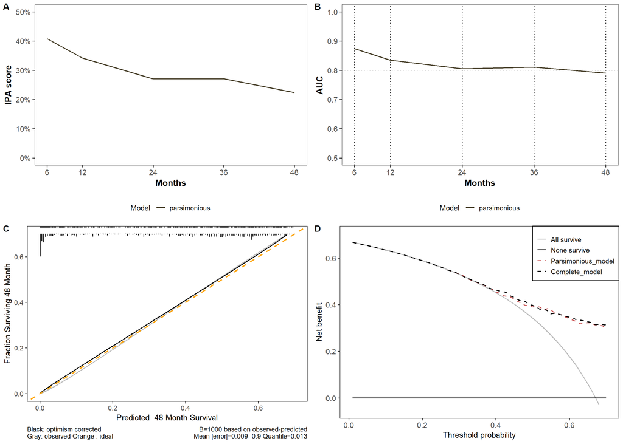

```r
#
# ggsave(fig3, filename = paste0(figuresPath,"/","Figure 3",".tiff"), dpi = 490,width = 14, height=10,
#        units = "in")
```

# 8 SUPPLEMENTARY mmc4 - MISSINGNESS ASSESSMENT

```r
# pat.mis <-md.pattern(data.all %>% dplyr::select(-LDH,-Year_of_diagnosis,-Age_categories) %>% dplyr::rename("Immunosuppressive\nmedication"="Steroids") %>% dplyr::rename("CNS metastases"="Brain_metastases"), rotate.names = TRUE)


data.Mis <- data.all %>% dplyr::select(-LDH,-Year_of_diagnosis,-Age_categories,-STAGE,-Stage_Brain_mets)
colnames(data.Mis) <- data.all %>% dplyr::select(-LDH,-Year_of_diagnosis,-Age_categories,-STAGE,-Stage_Brain_mets) %>% names() %>% str_replace_all("_","\n")
colnames(data.Mis)[1] <- "Months"
data.Mis <- data.Mis %>% dplyr::rename("Immuno-_suppressive_medication"="Steroids") %>% dplyr::rename("CNS_metastases"="Brain\nmetastases")
aggr_plot <- aggr(data.Mis, col=c('navyblue','red'), numbers=TRUE, sortVars=TRUE,
                  labels=data.Mis %>% names() %>% str_replace_all("_","\n"), cex.axis=.6, gap=3, ylab=c("Histogram of missing data","Pattern"))
```

```
##
##  Variables sorted by number of missings:
##                          Variable      Count
##                        LDH\nlevel 0.07491857
##                      BRAF\nstatus 0.02768730
##               Performance\nstatus 0.01628664
##                            Months 0.00000000
##                   Dead\nor\nalive 0.00000000
##                            Gender 0.00000000
##             Age\nfirst\nTreatment 0.00000000
##           First\nline\ntreatments 0.00000000
##                   CNS\nmetastases 0.00000000
##                    Disease\nstage 0.00000000
##  Immuno-\nsuppressive\nmedication 0.00000000
##                     Comorbidities 0.00000000
##                      Autoimmunity 0.00000000
##               Other\nmalignancies 0.00000000
```

```r
cairo_pdf(filename = paste0(figuresPath,"/","Missingness Assessment",".pdf"),width = 15, height=7,family ="Palatino")
  aggr(data.Mis, col=c('navyblue','red'), numbers=TRUE, sortVars=TRUE,
                  labels=data.Mis %>% names() %>% str_replace_all("_","\n"), cex.axis=.7, gap=3, ylab=c("Histogram of missing data","Pattern"))
```

```
##
##  Variables sorted by number of missings:
##                          Variable      Count
##                        LDH\nlevel 0.07491857
##                      BRAF\nstatus 0.02768730
##               Performance\nstatus 0.01628664
##                            Months 0.00000000
##                   Dead\nor\nalive 0.00000000
##                            Gender 0.00000000
##             Age\nfirst\nTreatment 0.00000000
##           First\nline\ntreatments 0.00000000
##                   CNS\nmetastases 0.00000000
##                    Disease\nstage 0.00000000
##  Immuno-\nsuppressive\nmedication 0.00000000
##                     Comorbidities 0.00000000
##                      Autoimmunity 0.00000000
##               Other\nmalignancies 0.00000000
```

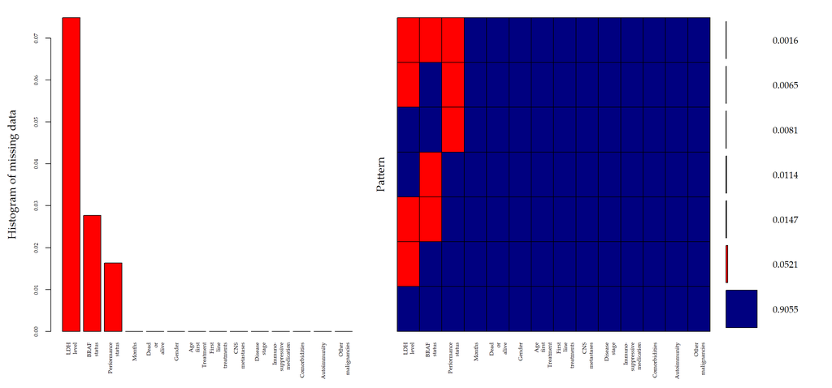

```r
dev.off()
```

# 9 SUPP FIG 1: COX PH assumptions

```r
######################
# ORIGINAL FEATURES
featuresIn.cn.orig <-c("Gender","Age_first_Treatment",
              "Stage_Brain_mets","Steroids","Comorbidities","Autoimmunity","Other malignancies","Performance status","BRAF status","LDH_level","First_line_treatments")
featuresIn.cn.orig <- str_replace_all(str_replace_all(featuresIn.cn.orig," ","_"),"-","_")
featuresInLabels.cn.orig <- c("Gender","Age",
              "Disease stage and Brain metastases","Steroids","Comorbidities","Autoimmunity","Other malignancies","Performance status","BRAF status","LDH level","First line Treatment")

numeric_feats.orig<- c("Age_first_Treatment","LDH_level")
categ_feats.orig <- setdiff(featuresIn.cn.orig,numeric_feats.orig)

# FINAL FEATURES FOR MI/MODELLING
featuresIn.cn <-c("Gender","Age_first_Treatment",
              "Stage_Brain_mets","Steroids","Comorbidities","Autoimmunity","Other malignancies","Performance status","BRAF status","LDH_level.log","First_line_treatments")
featuresIn.cn <- str_replace_all(str_replace_all(featuresIn.cn," ","_"),"-","_")

numeric_feats<- c("Age_first_Treatment","LDH_level.log")
categ_feats <- setdiff(featuresIn.cn,numeric_feats)
# When I manually add rcs of age for MI with smcfcs
numeric_feats.ext <- c(numeric_feats[1],"Age_first_Treatment_1",numeric_feats[2])
```

```r
# First define  transformations in original data
data.original <- data.all %>% dplyr::select(all_of(c(surv_time, surv_status,featuresIn.cn.orig))) %>% droplevels()
# Create LDH log
data.original.ext <- cbind(data.original, LDH_level.log=log(data.original$LDH_level))

# Create complete data-extended version
data.complete <- data.original.ext %>% dplyr::filter(complete.cases(.)) %>% droplevels()
```

```r
feats2 <-makeComplexFormula(features=c(categ_feats,numeric_feats.ext[3]),
                   rcsFeats=c(numeric_feats.ext[1]),
                   knots=c(3),
                   interactions=NULL,
                   strataFeats=NULL,
                   rms=T)

p2 <-plotExploreInteractions(features=feats2,data=data.complete, problematic=NULL,toRemove=NULL)
```

```
## X matrix deemed to be singular; variable First_line_treatments=BRAFi * BRAF_status=Mutant
## [1] "No interactions evaluated, no model fitted: X matrix deemed to be singular"
```

```r
# p2$plots
```

```r
inters2 <- p2$combos[c(1,2,4,8,11,12,13,16,17,19,21,24,25,27,30,32,34,35,36,37,38,39,43,44,45,47,49,51,52,53,54,55)]

featsInters2 <-makeComplexFormula(features=c(categ_feats,numeric_feats.ext[3]),
                   rcsFeats=c(numeric_feats.ext[1]),
                   knots=c(3),
                   interactions=inters2,
                   strataFeats=NULL,
                   rms=T)

explorePH.inter.trans.strata.nointer=explorePH.inter.trans(data=data.complete, time=surv_time, status=surv_status,
                      features=feats2, inters=featsInters2)

# explorePH.inter.trans.strata.nointer$model_stats
# explorePH.inter.trans.strata.nointer$phtest.sign$nointer
# explorePH.inter.trans.strata.nointer$anova.inter.res
```

```r
supp1 <-explorePH.inter.trans.strata.nointer$ph.plots$nointer
supp1$`3`<-supp1$`3` +labs(y="Beta(t) for\nImmunosuppressive\nmedications")

supp1$`2` <- supp1$`2` +labs(y="Disease stage &\nCNS metastases")
supp1$`10` <- supp1$`10` +labs(y="LDH level\n(log)")
supp1$`11` <- supp1$`11` +labs(y="rcs(Age,3)")
supp1$`6` <- supp1$`6` +labs(y="Other malignancies")
supp1$`7` <- supp1$`7` +labs(y="Performance\nstatus")
supp1$`8` <- supp1$`8` +labs(y="BRAF\nstatus")
supp1$`9` <- supp1$`9` +labs(y="First-line\ntreatment")



supp1
cairo_pdf(filename = paste0(figuresPath,"/","Supplementary Figure 1",".pdf"),width = 16, height=14,family ="Palatino")
  print(supp1)
dev.off()
```

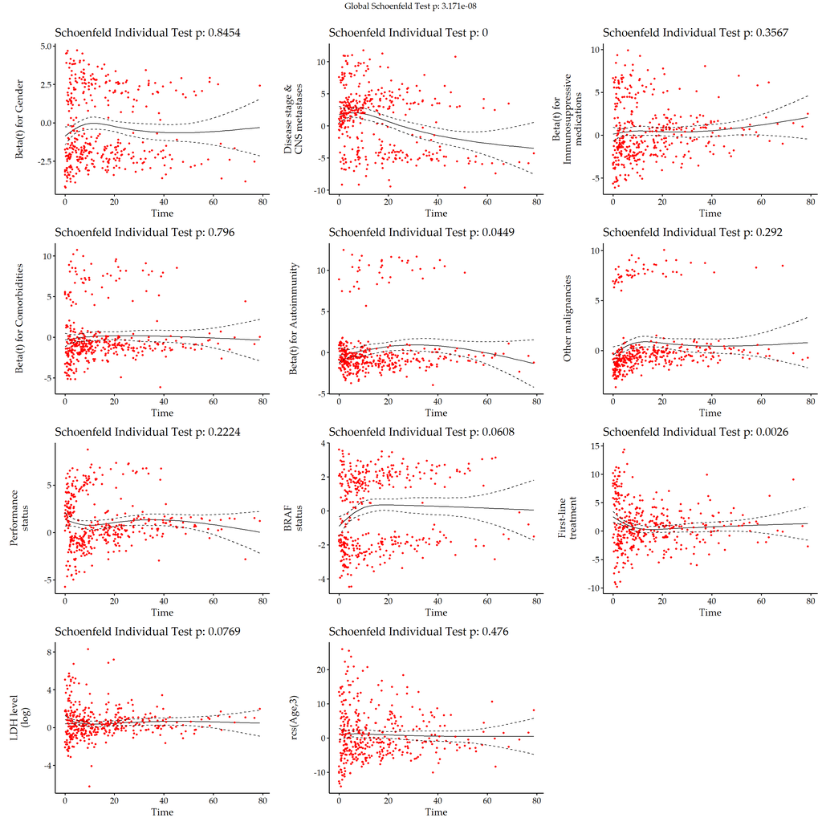

```r
#
# ggsave(print(supp1), filename = paste0(figuresPath,"/","Supp1_4YEARS",".tiff"), dpi = 490,width = 16, height=16,
#        units = "in")
```

# 10 SUPP FIG 3: patient flow chart

Provided in output/figures folder, created with Visio.

# 11 SUPP FIG 4: Model stability for parsimonious model

```r
bif.df<- melt(resCox_MI_boot.strata.nointer.bw_RED$mice.bw$stability$bif_perc) %>% rownames_to_column(var="variable")
bif.df$variable <- ifelse(bif.df$variable=="Steroids","Immunosuppressive\nmedications",bif.df$variable)
bif.df$variable <- ifelse(bif.df$variable=="Stage_Brain_mets","Disease stage &\nCNS metastases",bif.df$variable)
bif.df$variable <- ifelse(bif.df$variable=="LDH_level.log","LDH level\n(log)",bif.df$variable)
bif.df$variable <- ifelse(bif.df$variable=="rcs(Age_first_Treatment,3)","rcs(Age,3)",bif.df$variable)


bif.df$variable <- bif.df$variable %>% str_replace_all("_","\n")
bif.df$variable <- factor(bif.df$variable, levels = bif.df$variable %>% rev())


BIF.bar <-mybarplot(bif.df,xVar="variable",yVar="value",xLabel="Feature",yLabel="Bootstrap Inclusion Frequency in % (BIF)",facetVar=NULL,bootFreq=50)
```

```r
# Models during validation with BW
validation_stabModels <-resCox_MI_boot.strata.nointer.bw_RED$mice.bw$stability$model_stab %>%
  dplyr::select(-freq)

validation_stabModels$model <- paste0("M",1:nrow(validation_stabModels))

validation_stabModels.DF <-validation_stabModels %>% pivot_longer(-c(bif_pat_perc,model),names_to = "predictor",values_to = "value")

validation_stabModels.DF$predictor <- factor(validation_stabModels.DF$predictor,
                                             levels=validation_stabModels.DF$predictor %>% unique() )

validation_stabModels.DF$model <- factor(validation_stabModels.DF$model, levels=validation_stabModels.DF$model %>% unique() %>% rev())
validation_stabModels.DF$value <- validation_stabModels.DF$value %>% factor()

valid_plot <-myTileHeatPlot.2(DF=validation_stabModels.DF, xVar="predictor", yVar="model",xLabel="", yLabel="", labelVar=NULL, colorVar="value", facetVar = NULL )

## FINAL MODEL
# Final model with BW
final_model.DF <- finalModel_noInter$pool_coxr.cox.nointer.bw$predictors_out %>% tail(n=1) %>% melt %>% dplyr::select(-Var1) %>% setNames(c("predictor","value")) %>% mutate(model="Final model")

# Change 0 to 1 and 1 to zero, to have as 1 those included
final_model.DF$value <- ifelse(final_model.DF$value==0,1,0)
final_model.DF$predictor <- as.character(final_model.DF$predictor)
final_model.DF$predictor <- ifelse(final_model.DF$predictor=="Steroids","Immunosuppressive\nmedications",final_model.DF$predictor)

final_model.DF$predictor <- ifelse(final_model.DF$predictor=="Stage_Brain_mets","Disease stage &\nCNS metastases",final_model.DF$predictor)

final_model.DF$predictor <- ifelse(final_model.DF$predictor=="LDH_level.log","LDH level\n(log)",final_model.DF$predictor)
final_model.DF$predictor <- ifelse(final_model.DF$predictor=="rcs(Age_first_Treatment,3)","rcs(Age,3)",final_model.DF$predictor)


final_model.DF$predictor <- final_model.DF$predictor %>% str_replace_all("_"," ")

final_model.DF$predictor <- factor(final_model.DF$predictor,
                                             levels=final_model.DF$predictor %>% unique() )

final_model.DF$model <- factor(final_model.DF$model, levels=final_model.DF$model %>% unique() %>% rev())
final_model.DF$value <- final_model.DF$value %>% factor()


final_plot <-myTileHeatPlot.2(DF=final_model.DF, xVar="predictor", yVar="model",xLabel="", yLabel="", labelVar=NULL, colorVar="value", facetVar = NULL )
```

Validation models BIF

```r
# validation_stabModels.DF
colnames(validation_stabModels.DF)[1] <- "BIF %"
valid_BIF_plot <-myTileHeatPlot.2(DF=validation_stabModels.DF %>% dplyr::select(-predictor,-value) %>% melt(),
                 xVar="variable",
                 yVar="model",
                 xLabel="",
                 yLabel="",
                 labelVar=NULL,
                 colorVar="value",
                 colorCont = T,
                 facetVar = NULL,removeLegend=FALSE )

validPlots_merged <-(valid_plot + theme(axis.text.y=element_blank()) | (valid_BIF_plot+ theme(axis.text.y=element_blank()))) + patchwork::plot_layout(widths = c(9,1))
# validPlots_merged


validPlots_merged2 <-((valid_plot+ theme(axis.text.x=element_blank(),
                                         axis.text.y=element_blank())) | (valid_BIF_plot+ theme(axis.text.y=element_blank()))) + patchwork::plot_layout(widths = c(9,1))
# validPlots_merged2
```

```r
final_plot2 <- (final_plot + theme(axis.text=element_text(size=12,face="bold",angle = 25,vjust=1, hjust=-.02))+ patchwork::plot_spacer())+ patchwork::plot_layout(widths = c(8.9,1.1))

bootModels.plot <-(final_plot2)/(validPlots_merged2) + patchwork::plot_layout(heights = c(1, 9))
```

```r
supp4 <- BIF.bar + bootModels.plot + patchwork::plot_layout(widths = c(1.5, 8.5)) + plot_annotation(tag_levels = list(c("A","B"))) &
  theme(plot.tag = element_text(size = 14))
supp4
cairo_pdf(filename = paste0(figuresPath,"/","Supplementary Figure 4",".pdf"),width = 20, height=8,family ="Palatino")
  print(supp4)
dev.off()
```

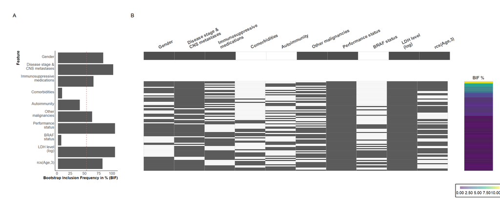

```r
# ggsave(supp4, filename = paste0(figuresPath,"/","Supplementary Figure 4",".tiff"), dpi = 490,width = 20.5, height=8,
#        units = "in")
```

# 12 SUPP FIG 5: Calibration curves of the final parsimonious model for 6-month, 1-year (12 months), 2-year (24 months), and 3-year (36 months) OS

```r
cal.final.other <-sapply(c("6","12","24", "36"), function(x) calibrationGGplot(calObj=res.cal.strat.nointer_RED$mice.bw[[x]]$cal,optCorColor="Orange"), simplify=FALSE)
# cal.treat_strata.red.bw

# # Calibration for 42 months

supp5 <- ggarrange(plotlist = cal.final.other,ncol = 2,nrow=2, common.legend = FALSE, labels = c("A", "B", "C","D"),font.label = list(size = 14, color = "black", face = "bold", family = "Palatino"))

supp5

cairo_pdf(filename = paste0(figuresPath,"/","Supplementary Figure 5",".pdf"),width = 14, height=10,family ="Palatino")
  print(supp5)
dev.off()
```

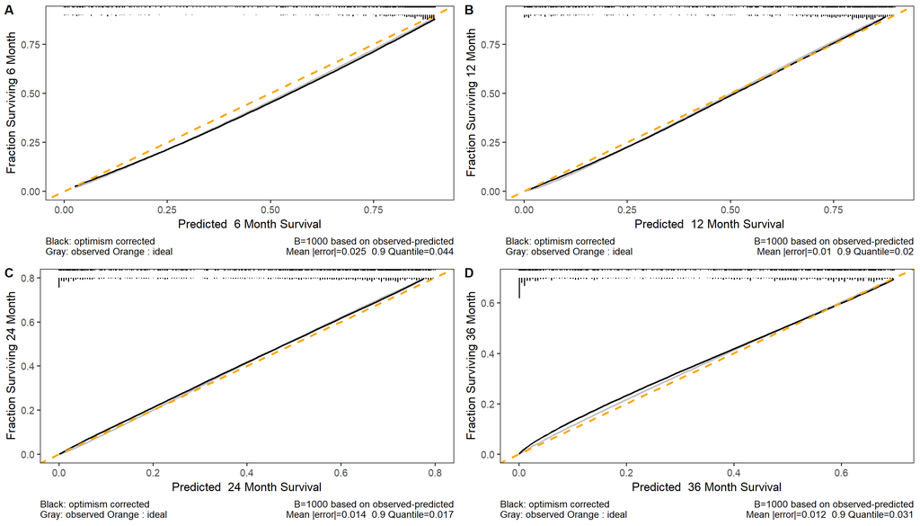

```r
#
# ggsave(supp5, filename = paste0(figuresPath,"/","Supplementary Figure 5",".tiff"), dpi = 490,width = 14, height=10,
#        units = "in")
```